# F1 vs. F0 cue-weighting in Children

# 1. Load necessary libraries 📚

[output not shown]

# 2. Load data 📊

```r
# 1. Set the Working Directory 📁
# --------------------------------------------------------
# Set the working directory to the path where your data files are stored
setwd("/Users/jeremygenette_studio/Documents/Research/Code/IF0_babbling_lexical/Data/")
# 2. Load Data Files 📄
# --------------------------------------------------------
# Load the main data frame for analysis from an RDS file
df <-readRDS("/Users/jeremygenette_studio/Documents/Research/Code/IF0_babbling_lexical/Data/df_vf_for_analysis.rds")

# Load a supplementary data frame containing Child Babbling Ratio (CBR) data

df_CBR <-readRDS("/Users/jeremygenette_studio/Documents/Research/Code/IF0_babbling_lexical/Data/df_CBR.rds")

# 3. Round Numeric Columns in the Main Data Frame 🔢
# --------------------------------------------------------
# Round numeric columns to 3 decimal places, leaving lexical columns unchanged
df_RQ2 <- as.data.frame(lapply(df, function(x) if (is.numeric(x)) round(x, 3) else x))

# 4. Merge Data Frames 🔗
# --------------------------------------------------------
# Merge the main data frame with the CBR data frame by "CHILD" and "AGE"
df_RQ2 <- left_join(df_RQ2, df_CBR, by = c("CHILD", "AGE"))

# 5. Create "frontness" Column (Vowel Frontness) 🔤
# --------------------------------------------------------

# Rename CHILD column with unique anonymous identifiers
if ("CHILD" %in% colnames(df_RQ2)) {
  df_RQ2$CHILD <- factor(df_RQ2$CHILD)  # Ensure it's a factor
  levels(df_RQ2$CHILD) <- paste("Child", seq_along(levels(df_RQ2$CHILD)))  # Rename levels
}


# 6. Filter, Transform, and Tidy the Data 🛠️
# --------------------------------------------------------
df_RQ2 <- df_RQ2 %>%
  filter(type == "prelexical") %>%           # Retain only "prelexical" type rows
  group_by(CHILD) %>%                        # Group by "CHILD" for scaling
  mutate(
    item = as.factor(item),                 # Convert "item" to a factor
    hgt = as.factor(hgt),                   # Convert "hgt" (height) to a factor
    CHILD = as.factor(CHILD),               # Convert "CHILD" to a factor
    period = ifelse(AGE_ctrd <= 0, "prelexical", "lexical") # Define "period" based on CBR values
  ) %>%
  ungroup()  %>%
  select(
    -c(item, ID_vwl, type, F1_F0_distance, F0, F1, first_word, F1_F0_distance,  cumvoc)
  ) %>%
  filter(period == "lexical") # Drop unnecessary columns

contrasts(df_RQ2$hgt) <- contr.sum(levels(df_RQ2$hgt))
df_RQ2$hgt <- relevel(df_RQ2$hgt, ref = "low")
# 7. Final Output Preview 🔍
# --------------------------------------------------------
# Print the first few rows of the preprocessed data frame
print(head(df_RQ2))
```

| CHILD | vwl_nucl | F0_Regression_Normalized | F1_Regression_Normalized | hgt | AGE | AGE.IN.DAYS | AGE_ctrd | CBR | period |
| --- | --- | --- | --- | --- | --- | --- | --- | --- | --- |
| Child 1 | cop | 1.527 | 1.030 | low | 15 | 466.75 | 1 | 0.3747867 | lexical |
| Child 1 | cop | 1.014 | 1.252 | low | 15 | 466.75 | 1 | 0.3747867 | lexical |
| Child 1 | cop | 0.433 | 1.314 | low | 15 | 466.75 | 1 | 0.3747867 | lexical |
| Child 1 | cop | 0.971 | 1.807 | low | 15 | 466.75 | 1 | 0.3747867 | lexical |
| Child 1 | cop | 0.377 | 1.291 | low | 15 | 466.75 | 1 | 0.3747867 | lexical |
| Child 1 | aop | -0.454 | -0.088 | low | 15 | 466.75 | 1 | 0.3747867 | lexical |

```r
setwd("/Users/jeremygenette_studio/Documents/Research/Code/IF0_babbling_lexical/")
dir.create("models", showWarnings = FALSE)
```

# 3. Statistical Modelling 📊

### Model 1: Intercept-only Model

```r
m1 <- glmer(
  data = df_RQ2,
  formula = hgt ~ 1 + (1 | CHILD),
  family = binomial(link = "logit"),
  control = glmerControl(optimizer = "bobyqa", optCtrl = list(maxfun = 2000000))
)

saveRDS(m1, file = "models/m1_intercept_only_RQ2_prelex.rds")
```

### Model 2: Fixed Effect of F1

```r
m2_fixed_F1 <- glmer(
  data = df_RQ2,
  formula = hgt ~ F1_Regression_Normalized + (1 | CHILD),
  family = binomial(link = "logit"),
  control = glmerControl(optimizer = "bobyqa", optCtrl = list(maxfun = 10000000))
)

saveRDS(m2_fixed_F1, file = "models/m2_F1_fixed_effect_RQ2_prelex.rds")
anova_results_m2 <- anova(m1, m2_fixed_F1)
print(anova_results_m2)
```

```
Data: df_RQ2
Models:
m1: hgt ~ 1 + (1 | CHILD)
m2_fixed_F1: hgt ~ F1_Regression_Normalized + (1 | CHILD)
            npar     AIC     BIC  logLik deviance  Chisq Df Pr(>Chisq)
m1             2 13234.2 13248.9 -6615.1  13230.2
m2_fixed_F1    3  9219.7  9241.7 -4606.8   9213.7 4016.5  1  < 2.2e-16 ***
---
Signif. codes:  0 ‘***’ 0.001 ‘**’ 0.01 ‘*’ 0.05 ‘.’ 0.1 ‘ ’ 1
```

➡️ The added predictor F1_Regression_Normalized significantly improves the model fit and was retained for further analysis.

### Model 3: Random Slope for F1

```r
m3_random_slope_F1 <- glmer(
  data = df_RQ2,
  formula = hgt ~ F1_Regression_Normalized + (1 + F1_Regression_Normalized | CHILD),
  family = binomial(link = "logit"),
  control = glmerControl(optimizer = "bobyqa", optCtrl = list(maxfun = 10000000))
)

saveRDS(m3_random_slope_F1, file = "models/m3_random_slope_F1_RQ2_prelex.rds")
anova_results_m3 <- anova(m2_fixed_F1, m3_random_slope_F1)
print(anova_results_m3)
```

```
Data: df_RQ2
Models:
m2_fixed_F1: hgt ~ F1_Regression_Normalized + (1 | CHILD)
m3_random_slope_F1: hgt ~ F1_Regression_Normalized + (1 + F1_Regression_Normalized | CHILD)
                   npar    AIC    BIC  logLik deviance Chisq Df Pr(>Chisq)
m2_fixed_F1           3 9219.7 9241.7 -4606.8   9213.7
m3_random_slope_F1    5 9024.3 9060.9 -4507.1   9014.3 199.4  2  < 2.2e-16 ***
---
Signif. codes:  0 ‘***’ 0.001 ‘**’ 0.01 ‘*’ 0.05 ‘.’ 0.1 ‘ ’ 1
```

➡️ The added random slope for F1_Regression_Normalized significantly improves the model fit and was retained for further analysis.

### Model 4: Fixed Effect of F0

```r
m4_fixed_F0 <- glmer(
  data = df_RQ2,
  formula = hgt ~ F1_Regression_Normalized + F0_Regression_Normalized + (1 + F1_Regression_Normalized | CHILD),
  family = binomial(link = "logit"),
  control = glmerControl(optimizer = "bobyqa", optCtrl = list(maxfun = 10000000))
)

saveRDS(m4_fixed_F0, file = "models/m4_fixed_F0_RQ2_prelex.rds")
anova_results_m4 <- anova(m3_random_slope_F1, m4_fixed_F0)
print(anova_results_m4)
```

```
Data: df_RQ2
Models:
m3_random_slope_F1: hgt ~ F1_Regression_Normalized + (1 + F1_Regression_Normalized | CHILD)
m4_fixed_F0: hgt ~ F1_Regression_Normalized + F0_Regression_Normalized + (1 + F1_Regression_Normalized | CHILD)
                   npar    AIC    BIC  logLik
m3_random_slope_F1    5 9024.3 9060.9 -4507.1
m4_fixed_F0           6 8572.5 8616.5 -4280.2
                   deviance  Chisq Df Pr(>Chisq)
m3_random_slope_F1   9014.3
m4_fixed_F0          8560.5 453.79  1  < 2.2e-16

m3_random_slope_F1
m4_fixed_F0        ***
---
Signif. codes:
0 ‘***’ 0.001 ‘**’ 0.01 ‘*’ 0.05 ‘.’ 0.1 ‘ ’ 1
```

➡️ The added predictor F0_Regression_Normalized significantly improves the model fit and was retained for further analysis.

### Model 5: Random Slope for F0

```r
m5_random_slope_F0 <- glmer(
  data = df_RQ2,
  formula = hgt ~ F1_Regression_Normalized + F0_Regression_Normalized + (1 + F1_Regression_Normalized  + F0_Regression_Normalized | CHILD),
  family = binomial(link = "logit"),
  control = glmerControl(optimizer = "bobyqa", optCtrl = list(maxfun = 10000000))
)

save(m5_random_slope_F0, file = "models/m5_random_slope_F0_RQ2_prelex.rds")
anova_results_m5 <- anova(m4_fixed_F0, m5_random_slope_F0)
print(anova_results_m5)
```

```
Data: df_RQ2
Models:
m4_fixed_F0: hgt ~ F1_Regression_Normalized + F0_Regression_Normalized + (1 + F1_Regression_Normalized | CHILD)
m5_random_slope_F0: hgt ~ F1_Regression_Normalized + F0_Regression_Normalized + (1 + F1_Regression_Normalized + F0_Regression_Normalized | CHILD)
                   npar    AIC    BIC  logLik deviance  Chisq Df
m4_fixed_F0           6 8572.5 8616.5 -4280.2   8560.5
m5_random_slope_F0    9 8536.9 8602.9 -4259.5   8518.9 41.561  3
                   Pr(>Chisq)
m4_fixed_F0
m5_random_slope_F0  4.971e-09 ***
---
Signif. codes:  0 ‘***’ 0.001 ‘**’ 0.01 ‘*’ 0.05 ‘.’ 0.1 ‘ ’ 1
```

➡️ The added random slope for F0_Regression_Normalized significantly improves the model fit and was retained for further analysis.

### Model 6: Fixed effect of CBR

```r
m6_fixed_CBR <- glmer(
  data = df_RQ2,
  formula = hgt ~ F1_Regression_Normalized + F0_Regression_Normalized + CBR + (1 + F1_Regression_Normalized + F0_Regression_Normalized  | CHILD),
  family = binomial(link = "logit"),
  control = glmerControl(optimizer = "bobyqa", optCtrl = list(maxfun = 10000000))
)

saveRDS(m6_fixed_CBR, file = "models/m6_fixed_CBR_RQ2_prelex.rds")
anova_results_m6 <- anova(m5_random_slope_F0, m6_fixed_CBR)
print(anova_results_m6)
```

```
Data: df_RQ2
Models:
m5_random_slope_F0: hgt ~ F1_Regression_Normalized + F0_Regression_Normalized + (1 + F1_Regression_Normalized + F0_Regression_Normalized | CHILD)
m6_fixed_CBR: hgt ~ F1_Regression_Normalized + F0_Regression_Normalized + CBR + (1 + F1_Regression_Normalized + F0_Regression_Normalized | CHILD)
                   npar    AIC    BIC  logLik deviance  Chisq Df Pr(>Chisq)
m5_random_slope_F0    9 8536.9 8602.9 -4259.5   8518.9
m6_fixed_CBR         10 8532.7 8606.1 -4256.4   8512.7 6.1735  1    0.01297 *
---
Signif. codes:  0 ‘***’ 0.001 ‘**’ 0.01 ‘*’ 0.05 ‘.’ 0.1 ‘ ’ 1
```

➡️ The added predictor CBR significantly improves the model fit and was retained for further analysis.

### Model 7: Random Slope for CBR

```r
m7_random_slope_CBR <- glmer(
  data = df_RQ2,
  formula = hgt ~ F1_Regression_Normalized + F0_Regression_Normalized + CBR + (1 + F1_Regression_Normalized + F0_Regression_Normalized  | CHILD)+(0+CBR|CHILD),
  family = binomial(link = "logit"),
  control = glmerControl(optimizer = "bobyqa", optCtrl = list(maxfun = 10000000))
)

saveRDS(m7_random_slope_CBR, file = "models/m7_random_slope_CBR_RQ2_prelex.rds")
anova_results_m7 <- anova(m6_fixed_CBR, m7_random_slope_CBR)
print(anova_results_m7)
```

```
Data: df_RQ2
Models:
m6_fixed_CBR: hgt ~ F1_Regression_Normalized + F0_Regression_Normalized + CBR + (1 + F1_Regression_Normalized + F0_Regression_Normalized | CHILD)
m7_random_slope_CBR: hgt ~ F1_Regression_Normalized + F0_Regression_Normalized + CBR + (1 + F1_Regression_Normalized + F0_Regression_Normalized | CHILD) + (0 + CBR | CHILD)
                    npar    AIC    BIC  logLik deviance Chisq Df Pr(>Chisq)
m6_fixed_CBR          10 8532.7 8606.1 -4256.4   8512.7
m7_random_slope_CBR   11 8514.4 8595.1 -4246.2   8492.4 20.35  1  6.449e-06 ***
---
Signif. codes:  0 ‘***’ 0.001 ‘**’ 0.01 ‘*’ 0.05 ‘.’ 0.1 ‘ ’ 1
```

➡️ The added random slope for CBR significantly improves the model fit and was retained for further analysis.

### Model 8: Quadratic effect of CBR

```r
m8_quadratic_CBR <- glmer(
  data = df_RQ2,
  formula = hgt ~ F1_Regression_Normalized + F0_Regression_Normalized + CBR + I(CBR^2)   + (1 + F1_Regression_Normalized+F0_Regression_Normalized   | CHILD)+(0+CBR|CHILD),
  family = binomial(link = "logit"),
  control = glmerControl(optimizer = "bobyqa", optCtrl = list(maxfun = 10000000))
)

saveRDS(m8_quadratic_CBR, file = "models/m8_quadratic_CBR_RQ2_prelex.rds")
anova_results_m8 <- anova(m7_random_slope_CBR, m8_quadratic_CBR)
print(anova_results_m8)
```

```
Data: df_RQ2
Models:
m7_random_slope_CBR: hgt ~ F1_Regression_Normalized + F0_Regression_Normalized + CBR + (1 + F1_Regression_Normalized + F0_Regression_Normalized | CHILD) + (0 + CBR | CHILD)
m8_quadratic_CBR: hgt ~ F1_Regression_Normalized + F0_Regression_Normalized + CBR + I(CBR^2) + (1 + F1_Regression_Normalized + F0_Regression_Normalized | CHILD) + (0 + CBR | CHILD)
                    npar    AIC    BIC  logLik deviance Chisq Df Pr(>Chisq)
m7_random_slope_CBR   11 8514.4 8595.1 -4246.2   8492.4
m8_quadratic_CBR      12 8516.2 8604.3 -4246.1   8492.2 0.178  1     0.6731
```

➡️ The added quadratic effect of CBR significantly did not improve the model fit and was not retained for further analysis.

### Model 9: Interaction between F1 and F0

```r
m9_interaction_F1_F0 <- glmer(
  data = df_RQ2,
  formula = hgt ~ F1_Regression_Normalized + F0_Regression_Normalized + CBR +
    F1_Regression_Normalized : F0_Regression_Normalized + (1 + F1_Regression_Normalized + F0_Regression_Normalized  | CHILD)+(0+CBR|CHILD),
  family = binomial(link = "logit"),
  control = glmerControl(optimizer = "bobyqa", optCtrl = list(maxfun = 10000000))
)

saveRDS(m9_interaction_F1_F0, file = "models/m9_interaction_F1_F0_RQ2_prelex.rds")
anova_results_m9 <- anova(m7_random_slope_CBR, m9_interaction_F1_F0)
print(anova_results_m9)
```

```
Data: df_RQ2
Models:
m7_random_slope_CBR: hgt ~ F1_Regression_Normalized + F0_Regression_Normalized + CBR + (1 + F1_Regression_Normalized + F0_Regression_Normalized | CHILD) + (0 + CBR | CHILD)
m9_interaction_F1_F0: hgt ~ F1_Regression_Normalized + F0_Regression_Normalized + CBR + F1_Regression_Normalized:F0_Regression_Normalized + (1 + F1_Regression_Normalized + F0_Regression_Normalized | CHILD) + (0 + CBR | CHILD)
                     npar    AIC    BIC  logLik deviance Chisq Df Pr(>Chisq)
m7_random_slope_CBR    11 8514.4 8595.1 -4246.2   8492.4
m9_interaction_F1_F0   12 8507.7 8595.8 -4241.9   8483.7 8.654  1   0.003263 **
---
Signif. codes:  0 ‘***’ 0.001 ‘**’ 0.01 ‘*’ 0.05 ‘.’ 0.1 ‘ ’ 1
```

### Model 10: Interaction between F1 and CBR

```r
m10_interaction_F1_CBR <- glmer(
  data = df_RQ2,
  formula = hgt ~ F1_Regression_Normalized + F0_Regression_Normalized + CBR +
    F1_Regression_Normalized:F0_Regression_Normalized +
    F1_Regression_Normalized : CBR +
    (1 + F1_Regression_Normalized + F0_Regression_Normalized  | CHILD)+
    (0+CBR|CHILD),
  family = binomial(link = "logit"),
  control = glmerControl(optimizer = "bobyqa", optCtrl = list(maxfun = 10000000))
)

saveRDS(m10_interaction_F1_CBR, file = "models/m10_interaction_F1_CBR_RQ2_prelex.rds")
anova_results_m10 <- anova(m9_interaction_F1_F0, m10_interaction_F1_CBR)
print(anova_results_m10)
```

```
Data: df_RQ2
Models:
m9_interaction_F1_F0: hgt ~ F1_Regression_Normalized + F0_Regression_Normalized + CBR + F1_Regression_Normalized:F0_Regression_Normalized + (1 + F1_Regression_Normalized + F0_Regression_Normalized | CHILD) + (0 + CBR | CHILD)
m10_interaction_F1_CBR: hgt ~ F1_Regression_Normalized + F0_Regression_Normalized + CBR + F1_Regression_Normalized:F0_Regression_Normalized + F1_Regression_Normalized:CBR + (1 + F1_Regression_Normalized + F0_Regression_Normalized | CHILD) + (0 + CBR | CHILD)
                       npar    AIC    BIC  logLik deviance  Chisq Df Pr(>Chisq)
m9_interaction_F1_F0     12 8507.7 8595.8 -4241.9   8483.7
m10_interaction_F1_CBR   13 8459.4 8554.8 -4216.7   8433.4 50.347  1  1.289e-12 ***
---
Signif. codes:  0 ‘***’ 0.001 ‘**’ 0.01 ‘*’ 0.05 ‘.’ 0.1 ‘ ’ 1
```

➡️ The added interaction between F1_Regression_Normalized and CBR significantly improves the model fit and was retained for further analysis.

### Model 11: Interaction between F1 and quadratic CBR

```r
m11_interaction_F1_quadratic_CBR = glmer(
  data = df_RQ2,
  formula = hgt ~ F1_Regression_Normalized + F0_Regression_Normalized + CBR +
    F1_Regression_Normalized:F0_Regression_Normalized +
    F1_Regression_Normalized : (CBR + I(CBR^2)) + (1 + F1_Regression_Normalized + F0_Regression_Normalized   | CHILD)+(0+CBR|CHILD),
  family = binomial(link = "logit"),
  control = glmerControl(optimizer = "bobyqa", optCtrl = list(maxfun = 10000000))
)

saveRDS(m11_interaction_F1_quadratic_CBR, file = "models/m11_interaction_F1_quadratic_CBR_RQ2_prelex.rds")
anova_results_m11 <- anova(m10_interaction_F1_CBR, m11_interaction_F1_quadratic_CBR)
print(anova_results_m11)
```

```
Data: df_RQ2
Models:
m10_interaction_F1_CBR: hgt ~ F1_Regression_Normalized + F0_Regression_Normalized + CBR + F1_Regression_Normalized:F0_Regression_Normalized + F1_Regression_Normalized:CBR + (1 + F1_Regression_Normalized + F0_Regression_Normalized | CHILD) + (0 + CBR | CHILD)
m11_interaction_F1_quadratic_CBR: hgt ~ F1_Regression_Normalized + F0_Regression_Normalized + CBR + F1_Regression_Normalized:F0_Regression_Normalized + F1_Regression_Normalized:(CBR + I(CBR^2)) + (1 + F1_Regression_Normalized + F0_Regression_Normalized | CHILD) + (0 + CBR | CHILD)
                                 npar    AIC    BIC  logLik deviance Chisq Df Pr(>Chisq)
m10_interaction_F1_CBR             13 8459.4 8554.8 -4216.7   8433.4
m11_interaction_F1_quadratic_CBR   14 8442.6 8545.4 -4207.3   8414.6 18.75  1   1.49e-05 ***
---
Signif. codes:  0 ‘***’ 0.001 ‘**’ 0.01 ‘*’ 0.05 ‘.’ 0.1 ‘ ’ 1
```

➡️ The added interaction between F1_Regression_Normalized and CBR significantly improves the model fit and was retained for further analysis.

### Model 12: Interaction between F1 and cubic CBR

```r
m12_interaction_F1_cubic_CBR <- glmer(
  data = df_RQ2,
  formula = hgt ~ F1_Regression_Normalized + F0_Regression_Normalized + CBR +
    F1_Regression_Normalized:F0_Regression_Normalized +
    F1_Regression_Normalized : (CBR + I(CBR^2) + I(CBR^3)) + (1 + F1_Regression_Normalized + F0_Regression_Normalized   | CHILD)+(0+CBR|CHILD),
  family = binomial(link = "logit"),
  control = glmerControl(optimizer = "bobyqa", optCtrl = list(maxfun = 10000000))
)

saveRDS(m12_interaction_F1_cubic_CBR, file = "models/m12_interaction_F1_cubic_CBR_RQ2_prelex.rds")
anova_results_m12 <- anova(m11_interaction_F1_quadratic_CBR, m12_interaction_F1_cubic_CBR)
print(anova_results_m12)
```

```
Data: df_RQ2
Models:
m11_interaction_F1_quadratic_CBR: hgt ~ F1_Regression_Normalized + F0_Regression_Normalized + CBR + F1_Regression_Normalized:F0_Regression_Normalized + F1_Regression_Normalized:(CBR + I(CBR^2)) + (1 + F1_Regression_Normalized + F0_Regression_Normalized | CHILD) + (0 + CBR | CHILD)
m12_interaction_F1_cubic_CBR: hgt ~ F1_Regression_Normalized + F0_Regression_Normalized + CBR + F1_Regression_Normalized:F0_Regression_Normalized + F1_Regression_Normalized:(CBR + I(CBR^2) + I(CBR^3)) + (1 + F1_Regression_Normalized + F0_Regression_Normalized | CHILD) + (0 + CBR | CHILD)
                                 npar    AIC    BIC  logLik deviance Chisq Df Pr(>Chisq)
m11_interaction_F1_quadratic_CBR   14 8442.6 8545.4 -4207.3   8414.6
m12_interaction_F1_cubic_CBR       15 8444.0 8554.1 -4207.0   8414.0 0.626  1     0.4288
```

➡️ The added interaction between F1_Regression_Normalized and CBR significantly did not improve the model fit and was not retained for further analysis.

### Model 13: Interaction between F0 and CBR

```r
m13_interaction_F0_CBR <- glmer(
  data = df_RQ2,
  formula = hgt ~ F1_Regression_Normalized + F0_Regression_Normalized + CBR +
    F1_Regression_Normalized:F0_Regression_Normalized +
    F1_Regression_Normalized:(CBR + I(CBR^2)) +
    F0_Regression_Normalized : CBR + (1 + F1_Regression_Normalized + F0_Regression_Normalized   | CHILD)+(0+CBR|CHILD),
  family = binomial(link = "logit"),
  control = glmerControl(optimizer = "bobyqa", optCtrl = list(maxfun = 10000000))
)

saveRDS(m13_interaction_F0_CBR, file = "models/m13_interaction_F0_CBR_RQ2_prelex.rds")
anova_results_m13 <- anova(m11_interaction_F1_quadratic_CBR, m13_interaction_F0_CBR)
print(anova_results_m13)
```

```
Data: df_RQ2
Models:
m11_interaction_F1_quadratic_CBR: hgt ~ F1_Regression_Normalized + F0_Regression_Normalized + CBR + F1_Regression_Normalized:F0_Regression_Normalized + F1_Regression_Normalized:(CBR + I(CBR^2)) + (1 + F1_Regression_Normalized + F0_Regression_Normalized | CHILD) + (0 + CBR | CHILD)
m13_interaction_F0_CBR: hgt ~ F1_Regression_Normalized + F0_Regression_Normalized + CBR + F1_Regression_Normalized:F0_Regression_Normalized + F1_Regression_Normalized:(CBR + I(CBR^2)) + F0_Regression_Normalized:CBR + (1 + F1_Regression_Normalized + F0_Regression_Normalized | CHILD) + (0 + CBR | CHIL…
                                 npar    AIC    BIC  logLik deviance  Chisq Df Pr(>Chisq)
m11_interaction_F1_quadratic_CBR   14 8442.6 8545.4 -4207.3   8414.6
m13_interaction_F0_CBR             15 8435.5 8545.5 -4202.7   8405.5 9.1545  1   0.002481 **
---
Signif. codes:  0 ‘***’ 0.001 ‘**’ 0.01 ‘*’ 0.05 ‘.’ 0.1 ‘ ’ 1
```

### Model 14: Interaction between F0 and quadratic CBR

```r
m14_interaction_F0_quadratic_CBR <- glmer(
  data = df_RQ2,
  formula = hgt ~ F1_Regression_Normalized + F0_Regression_Normalized + CBR +
    F1_Regression_Normalized:F0_Regression_Normalized +
    F1_Regression_Normalized : (CBR + I(CBR^2)) +
    F0_Regression_Normalized : (CBR + I(CBR^2)) + (1 + F1_Regression_Normalized + F0_Regression_Normalized   | CHILD)+(0+CBR|CHILD),
  family = binomial(link = "logit"),
  control = glmerControl(optimizer = "bobyqa", optCtrl = list(maxfun = 10000000))
)

saveRDS(m14_interaction_F0_quadratic_CBR, file = "models/m14_interaction_F0_quadratic_CBR_RQ2_prelex.rds")
anova_results_m14 <- anova(m13_interaction_F0_CBR, m14_interaction_F0_quadratic_CBR)
print(anova_results_m14)
```

```
Data: df_RQ2
Models:
m13_interaction_F0_CBR: hgt ~ F1_Regression_Normalized + F0_Regression_Normalized + CBR + F1_Regression_Normalized:F0_Regression_Normalized + F1_Regression_Normalized:(CBR + I(CBR^2)) + F0_Regression_Normalized:CBR + (1 + F1_Regression_Normalized + F0_Regression_Normalized | CHILD) + (0 + CBR | CHIL…
m14_interaction_F0_quadratic_CBR: hgt ~ F1_Regression_Normalized + F0_Regression_Normalized + CBR + F1_Regression_Normalized:F0_Regression_Normalized + F1_Regression_Normalized:(CBR + I(CBR^2)) + F0_Regression_Normalized:(CBR + I(CBR^2)) + (1 + F1_Regression_Normalized + F0_Regression_Normalized | C…
                                 npar    AIC    BIC  logLik deviance  Chisq Df Pr(>Chisq)
m13_interaction_F0_CBR             15 8435.5 8545.5 -4202.7   8405.5
m14_interaction_F0_quadratic_CBR   16 8432.8 8550.2 -4200.4   8400.8 4.6482  1    0.03109 *
---
Signif. codes:  0 ‘***’ 0.001 ‘**’ 0.01 ‘*’ 0.05 ‘.’ 0.1 ‘ ’ 1
```

### Model 15: Interaction between F0 and cubic CBR

```r
m15_interaction_F0_cubic_CBR <- glmer(
  data = df_RQ2,
  formula = hgt ~ F1_Regression_Normalized + F0_Regression_Normalized + CBR +
    F1_Regression_Normalized:F0_Regression_Normalized +
    F1_Regression_Normalized : (CBR + I(CBR^2)) +
    F0_Regression_Normalized : (CBR + I(CBR^2) + I(CBR^3)) + (1 + F1_Regression_Normalized + F0_Regression_Normalized   | CHILD)+(0+CBR|CHILD),
  family = binomial(link = "logit"),
  control = glmerControl(optimizer = "bobyqa", optCtrl = list(maxfun = 10000000))
)

saveRDS(m15_interaction_F0_cubic_CBR, file = "models/m15_interaction_F0_cubic_CBR_RQ2_prelex.rds")
anova_results_m15 <- anova(m14_interaction_F0_quadratic_CBR, m15_interaction_F0_cubic_CBR)
print(anova_results_m15)
```

```
Data: df_RQ2
Models:
m14_interaction_F0_quadratic_CBR: hgt ~ F1_Regression_Normalized + F0_Regression_Normalized + CBR + F1_Regression_Normalized:F0_Regression_Normalized + F1_Regression_Normalized:(CBR + I(CBR^2)) + F0_Regression_Normalized:(CBR + I(CBR^2)) + (1 + F1_Regression_Normalized + F0_Regression_Normalized | C…
m15_interaction_F0_cubic_CBR: hgt ~ F1_Regression_Normalized + F0_Regression_Normalized + CBR + F1_Regression_Normalized:F0_Regression_Normalized + F1_Regression_Normalized:(CBR + I(CBR^2)) + F0_Regression_Normalized:(CBR + I(CBR^2) + I(CBR^3)) + (1 + F1_Regression_Normalized + F0_Regression_Normali…
                                 npar    AIC    BIC  logLik deviance  Chisq Df Pr(>Chisq)
m14_interaction_F0_quadratic_CBR   16 8432.8 8550.2 -4200.4   8400.8
m15_interaction_F0_cubic_CBR       17 8429.6 8554.4 -4197.8   8395.6 5.2018  1    0.02256 *
---
Signif. codes:  0 ‘***’ 0.001 ‘**’ 0.01 ‘*’ 0.05 ‘.’ 0.1 ‘ ’ 1
```

### Model 16: Interaction between F1, F0 and CBR

```r
m16_interaction_F1_F0_CBR <- glmer(
  data = df_RQ2,
  formula = hgt ~ F1_Regression_Normalized + F0_Regression_Normalized + CBR +
    F1_Regression_Normalized:F0_Regression_Normalized +
    F1_Regression_Normalized : (CBR + I(CBR^2)) +
    F0_Regression_Normalized : (CBR + I(CBR^2)+ I(CBR^3)) +
    F1_Regression_Normalized:F0_Regression_Normalized:CBR +
    (1 + F1_Regression_Normalized + F0_Regression_Normalized   | CHILD)+(0+CBR|CHILD),
  family = binomial(link = "logit"),
  control = glmerControl(optimizer = "bobyqa", optCtrl = list(maxfun = 10000000))
)

saveRDS(m16_interaction_F1_F0_CBR, file = "models/m16_interaction_F1_F0_CBR_RQ2_prelex.rds")
anova_results_m16 <- anova(m15_interaction_F0_cubic_CBR, m16_interaction_F1_F0_CBR)
print(anova_results_m16)
```

```
Data: df_RQ2
Models:
m15_interaction_F0_cubic_CBR: hgt ~ F1_Regression_Normalized + F0_Regression_Normalized + CBR + F1_Regression_Normalized:F0_Regression_Normalized + F1_Regression_Normalized:(CBR + I(CBR^2)) + F0_Regression_Normalized:(CBR + I(CBR^2) + I(CBR^3)) + (1 + F1_Regression_Normalized + F0_Regression_Normali…
m16_interaction_F1_F0_CBR: hgt ~ F1_Regression_Normalized + F0_Regression_Normalized + CBR + F1_Regression_Normalized:F0_Regression_Normalized + F1_Regression_Normalized:(CBR + I(CBR^2)) + F0_Regression_Normalized:(CBR + I(CBR^2) + I(CBR^3)) + F1_Regression_Normalized:F0_Regression_Normalized:CBR + …
                             npar    AIC    BIC  logLik deviance  Chisq Df Pr(>Chisq)
m15_interaction_F0_cubic_CBR   17 8429.6 8554.4 -4197.8   8395.6
m16_interaction_F1_F0_CBR      18 8409.4 8541.5 -4186.7   8373.4 22.236  1  2.411e-06 ***
---
Signif. codes:  0 ‘***’ 0.001 ‘**’ 0.01 ‘*’ 0.05 ‘.’ 0.1 ‘ ’ 1
```

➡️ Convegence issues were encountered with this model, and it was not retained for further analysis.

# 4. Results Summary 📊

```r
final_model <- m15_interaction_F0_cubic_CBR
print(summary(final_model))
```

```
Generalized linear mixed model fit by maximum likelihood (Laplace Approximation) ['glmerMod']
 Family: binomial  ( logit )
Formula: hgt ~ F1_Regression_Normalized + F0_Regression_Normalized + CBR +
    F1_Regression_Normalized:F0_Regression_Normalized + F1_Regression_Normalized:(CBR +
    I(CBR^2)) + F0_Regression_Normalized:(CBR + I(CBR^2) + I(CBR^3)) +      (1 + F1_Regression_Normalized + F0_Regression_Normalized |
        CHILD) + (0 + CBR | CHILD)
   Data: df_RQ2
Control: glmerControl(optimizer = "bobyqa", optCtrl = list(maxfun = 1e+07))

     AIC      BIC   logLik deviance df.resid
  8429.6   8554.4  -4197.8   8395.6    11327

Scaled residuals:
   Min     1Q Median     3Q    Max
 -28.8   -0.4   -0.2    0.3 7872.2

Random effects:
 Groups  Name                     Variance Std.Dev. Corr
 CHILD   (Intercept)              0.4469   0.6685
         F1_Regression_Normalized 3.8271   1.9563    0.39
         F0_Regression_Normalized 0.5685   0.7540   -0.16 -0.94
 CHILD.1 CBR                      0.9665   0.9831
Number of obs: 11344, groups:  CHILD, 30

Fixed effects:
                                                   Estimate Std. Error z value Pr(>|z|)
(Intercept)                                        -1.24826    0.19984  -6.246 4.20e-10 ***
F1_Regression_Normalized                          -13.25722    1.36362  -9.722  < 2e-16 ***
F0_Regression_Normalized                            0.34666    1.16446   0.298  0.76593
CBR                                                 0.88669    0.30891   2.870  0.00410 **
F1_Regression_Normalized:F0_Regression_Normalized  -0.24451    0.07807  -3.132  0.00174 **
F1_Regression_Normalized:CBR                       27.36589    4.37757   6.251 4.07e-10 ***
F1_Regression_Normalized:I(CBR^2)                 -18.91279    3.56819  -5.300 1.16e-07 ***
F0_Regression_Normalized:CBR                       16.64618    5.88804   2.827  0.00470 **
F0_Regression_Normalized:I(CBR^2)                 -42.88313   10.63067  -4.034 5.49e-05 ***
F0_Regression_Normalized:I(CBR^3)                  29.83210    6.58005   4.534 5.80e-06 ***
---
Signif. codes:  0 ‘***’ 0.001 ‘**’ 0.01 ‘*’ 0.05 ‘.’ 0.1 ‘ ’ 1

Correlation of Fixed Effects:
               (Intr) F1_Rg_N F0_Rg_N CBR    F1_R_N:F F1_R_N:C F1_R_N:I F0_R_N:C F0_R_N:I(CBR^2
F1_Rgrssn_N     0.140
F0_Rgrssn_N     0.006 -0.238
CBR            -0.628 -0.073  -0.018
F1_R_N:F0_R    -0.008 -0.003   0.007  -0.012
F1_Rg_N:CBR    -0.063 -0.947   0.209   0.061  0.008
F1_R_N:I(CB     0.050  0.911  -0.197  -0.048 -0.009   -0.988
F0_Rg_N:CBR     0.005  0.100  -0.923  -0.003 -0.016   -0.103    0.098
F0_R_N:I(CBR^2 -0.016  0.004   0.770   0.014  0.028   -0.005    0.008   -0.949
F0_R_N:I(CBR^3  0.018 -0.079  -0.601  -0.016 -0.038    0.088   -0.091    0.839   -0.966
```

```r
save.image("/Users/jeremygenette_studio/Documents/Research/Code/IF0_babbling_lexical/image_RQ2_lex.Rdata")
```

# 5. Plotting the Results 📈

[figure not shown]

```r
# Define color palettes
F1_color <- c("#8F3400", "#FF681F", "#FFBE8F")
F0_color <- c("#570887", "#A020F0", "#D387F8")

# Define a function for plotting
create_plot <- function(model, term1, term2, colors, y_label, x_label, legend_title) {
  plot <- plot_model(model, type = "pred", terms = c("CBR [all]", term2, term1)
                     , pred.type = "fe",
                     mdrt.values = "meansd"
                     ) +
    labs(
      color = legend_title,
      y = y_label,
      x = x_label,
      title = ""
    ) +
    theme_cowplot() +
    scale_color_manual(values = colors) +
    scale_fill_manual(values = colors) +
    scale_y_continuous(labels = scales::percent_format(), limits = c(0, 1)) +
    theme(legend.position = "bottom", legend.box = "horizontal")
  return(plot)
}

# Ensure the 'graph' folder exists
if (!dir.exists("graph")) dir.create("graph")

# Create and save plots for F1
plot_f1 <- create_plot(
  final_model,
  term1 = "CHILD",
  term2 = "F1_Regression_Normalized",
  colors = F1_color,
  y_label = "Predicted probability of a vowel being high",
  x_label = "CBR",
  legend_title = "Normalized F1"
)
plot_f1
ggsave("graph/RQ2_lex_plot_F1_child.png", plot_f1, width = 8, height = 8, dpi = 300)
```

[figure not shown]

```r
# Create and save plots for F0
plot_f0 <- create_plot(
  final_model,
  term1 = "CHILD",
  term2 = "F0_Regression_Normalized",
  colors = F0_color,
  y_label = "Predicted probability of a vowel being high",
  x_label = "CBR",
  legend_title = "Normalized F0"
)
plot_f0
ggsave("graph/RQ2_lex_plot_F0_child.png", plot_f0, width = 8, height = 8, dpi = 300)
```

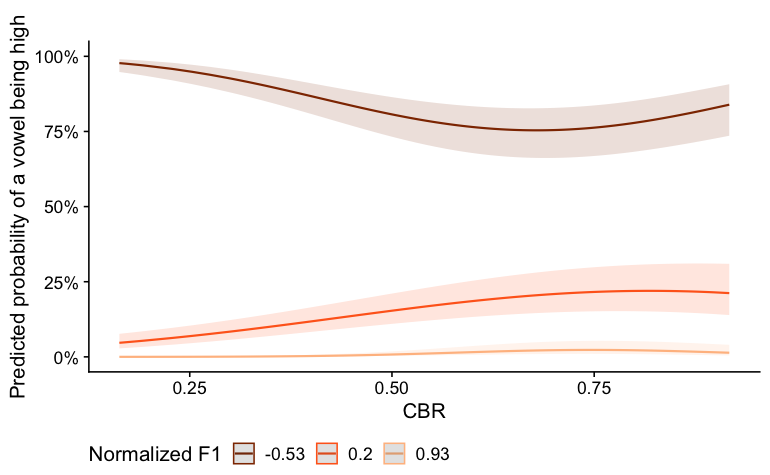

```r
# Create and save plots for F1 without CHILD factor
plot_f1_no_child <- create_plot(
  final_model,
  term1 = NULL,
  term2 = "F1_Regression_Normalized",
  colors = F1_color,
  y_label = "Predicted probability of a vowel being high",
  x_label = "CBR",
  legend_title = "Normalized F1"
)
plot_f1_no_child
ggsave("graph/RQ2_lex_plot_F1.png", plot_f1_no_child, width = 8, height = 6, dpi = 300)
```

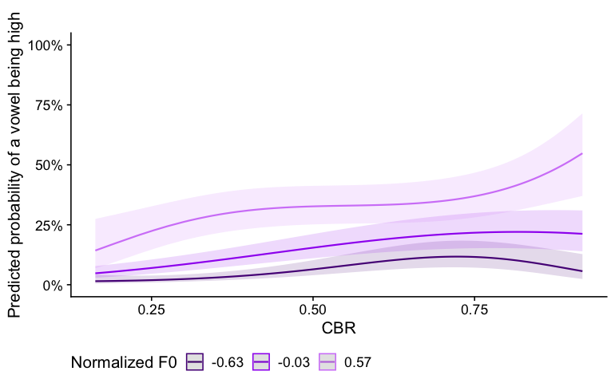

```r
# Create and save plots for F0 without CHILD factor
plot_f0_no_child <- create_plot(
  final_model,
  term1 = NULL,
  term2 = "F0_Regression_Normalized",
  colors = F0_color,
  y_label = "Predicted probability of a vowel being high",
  x_label = "CBR",
  legend_title = "Normalized F0"
)
plot_f0_no_child
ggsave("graph/RQ2_lex_plot_F0.png", plot_f0_no_child, width = 8, height = 6, dpi = 300)
```